[figure not shown]

МИНОБРНАУКИ РОССИИ  
Федеральное государственное бюджетное  
образовательное учреждение высшего образования

#### **«МИРЭА – Российский технологический униврситет»**

Лабораторная работа по дисциплине:  
«Программные средства оперативно-аналитического поиска»

Выполнил:  
Студент 4 курса  
Специальности 10.05.05  
Группа ББСО-02-16  
Поляков Д.А.  
Проверил:  
Захарчук И.И.

Москва 2020

#### **Лабораторная работа № 2**

#### **Цель работы**

Проанализировать сетевые параметры публичных DNS серверов, сделать мотивированный вывод о предпочтительных серверах

#### **Исходные данные**

| Наименование устройства | Операционная система |
| --- | --- |
| MacBook Pro (Retina 13 дюймов, начало 2015 г.) | MacOS Catalina 10.15.3 |

#### **Исследуемые провайдеры DNS**

1. [Google Public DNS](https://dns.google.com/)
2. [Cloudflare DNS](https://www.cloudflare.com/dns/)
3. [OpenDNS](https://www.opendns.com/)
4. [OnLime DNS](https://onlime.ru/)

#### **Используемое ПО**

1. Утилиты traceroute, ping и whois
2. Rstudio IDE

#### **Общий план выполнения работы**

1. Используя утилиты tracert/traceroute построить маршрут
2. На основании маршрута, используя утилиту whois узнать местоположение каждого узла маршрута к DNS-серверу, организацию, владеющую каждым узлом маршрута к DNS-серверу
3. Расчитать среднее RTT к DNS-серверу
4. Выделить те узлы маршрута, которые вносят наибольшую временную задержку при передаче

#### **Процесс выполнения работы**

- **Google Public DNS**

```r
system("traceroute 8.8.8.8", intern = TRUE)
```

```
##  [1] " 1  router.asus.com (192.168.1.1)  2.330 ms  1.120 ms  0.929 ms"
##  [2] " 2  broadband-90-154-77-211.ip.moscow.rt.ru (90.154.77.211)  1.919 ms  10.164 ms  1.863 ms"
##  [3] " 3  * 77.37.250.198 2.521 ms 3.061 ms"
##  [4] " 4  77.37.250.249 (77.37.250.249)  9.016 ms 3.127 ms 3.025 ms"
##  [5] " 5  72.14.209.81 (72.14.209.81)  9.480 ms  2.863 ms  3.404 ms"
##  [6] " 6  108.170.250.51 (108.170.250.51)  10.961 ms"
##  [7] "    108.170.250.146 (108.170.250.146)  5.168 ms"
##  [8] "    108.170.250.149 (108.170.250.149)  3.351 ms"
##  [9] " 7  209.85.249.158 (209.85.249.158)  19.233 ms"
## [10] "    216.239.50.2 (216.239.50.2)  19.654 ms"
## [11] "    172.253.66.116 (172.253.66.116)  21.235 ms"
## [12] " 8  216.239.41.196 (216.239.41.196)  18.227 ms"
## [13] "    209.85.254.6 (209.85.254.6)  18.347 ms 21.873 ms"
## [14] " 9  216.239.62.107 (216.239.62.107)  21.839 ms"
## [15] "    172.253.51.219 (172.253.51.219)  24.746 ms"
## [16] "    216.239.62.107 (216.239.62.107)  20.290 ms"
## [17] "10  * * *"
## [18] "11  * * *"
## [19] "12  * * *"
## [20] "13  * * *"
## [21] "14  * * *"
## [22] "15  * * *"
## [23] "16  * * *"
## [24] "17  * * *"

## [25] "18  * * *"
## [26] "19  dns.google (8.8.8.8)  18.952 ms * 26,983 ms"
```

| № | Первый ping | Второй ping | Третий ping | Узел | Месторасположение | Организация | Средняя RTT | Вносит наибольшую временную задержку при передаче |
| --- | --- | --- | --- | --- | --- | --- | --- | --- |
| 1 | 2 ms | 1 ms | 1 ms | 192.168.1.1 | Москва, Россия | Роутер | 1 |  |
| 2 | 2 ms | 10 ms | 2 ms | 90.154.77.211 | Лос-Анджелес, США | IANA | 7.3 |  |
| 3 | * | 2.5 ms | 3 ms | 77.37.250.198 | Москва, Россия | Ростелеком | 2 |  |
| 4 | 9 ms | 3 ms | 3 ms | 77.37.250.249 | Москва, Россия | Ростелеком | 5 |  |
| 5 | 9 ms | 3 ms | 3 ms | 72.14.209.81 | Маунтин-Вью, США | Google LLC | 5 |  |
| 6 | 11 ms | 5 ms | 3 ms | 108.170.250.149 | Маунтин-Вью, США | Google LLC | 6,3 |  |
| 7 | 19 ms | 20 ms | 21 ms | 209.85.249.158 | Маунтин-Вью, США | Google LLC | 20 | Да |
| 8 | 18 ms | 18 ms | 22 ms | 209.85.254.6 | Маунтин-Вью, США | Google LLC | 19,3 | Да |
| 9 | 22 ms | 25 ms | 20 ms | 172.253.51.219 | Маунтин-Вью, США | Google LLC | 22,3 | Да |
| 10 | * | * | * | Request timed out. |  |  |  |  |
| 11 | * | * | * | Request timed out. |  |  |  |  |
| 12 | * | * | * | Request timed out. |  |  |  |  |
| 13 | * | * | * | Request timed out. |  |  |  |  |
| 14 | * | * | * | Request timed out. |  |  |  |  |
| 15 | * | * | * | Request timed out. |  |  |  |  |
| 16 | * | * | * | Request timed out. |  |  |  |  |
| 17 | * | * | * | Request timed out. |  |  |  |  |
| 18 | * | * | * | Request timed out. |  |  |  |  |
| 19 | 19 ms | * | 27 ms | dns.google (8.8.8.8) | Нью-Йорк, США | Google LLC | 23 | Да |

- **Cloudflare DNS**

```r
system("traceroute 1.1.1.1", intern = TRUE)
```

```
##  [1] " 1  router.asus.com (192.168.1.1)  2.074 ms  0.937 ms  0.807 ms"
##  [2] " 2  broadband-90-154-77-211.ip.moscow.rt.ru (90.154.77.211)  2.324 ms  7.067 ms  7.981 ms"
##  [3] " 3  77.37.250.198 (77.37.250.198)  1.907 ms  3.350 ms  1.915 ms"
##  [4] " 4  * * 188.254.25.75 (188.254.25.75)  6.075 ms"

##  [5] " 5  213.59.212.217 (213.59.212.217)  5.075 ms"
##  [6] "    213.59.211.237 (213.59.211.237)  3.367 ms"
##  [7] "    188.254.25.77 (188.254.25.77)  18.892 ms"
##  [8] " 6  rostel-gw.ip4.gtt.net (77.67.90.97)  22.701 ms  20.860 ms  20.264 ms"
##  [9] " 7  ae1-500.cr1-stk3.ip4.gtt.net (77.67.90.96)  23.103 ms 21.158 ms  20.169 ms"
## [10] " 8  cloudflare-gw.cr0-stk3.ip4.gtt.net (141.136.101.178)  28.413 ms  23.170 ms  28.731 ms"
## [11] " 9  one.one.one.one (1.1.1.1)  21.984 ms  23.122 ms  20.037 ms"
```

| № | Первый ping | Второй ping | Третий ping | Узел | Месторасположение | Организация | Средняя RTT | Вносит наибольшую временную задержку при передаче |
| --- | --- | --- | --- | --- | --- | --- | --- | --- |
| 1 | 2 ms | 1 ms | 1 ms | 192.168.1.1 | Москва, Россия | Роутер | 1,3 |  |
| 2 | 2 ms | 7 ms | 8 ms | 90.154.77.211 | Лос-Анджелес, США | IANA | 5,6 |  |
| 3 | 2 ms | 3 ms | 2 ms | 77.37.250.198 | Москва, Россия | Ростелеком | 2,3 |  |
| 4 | 6 ms | * | * | 188.254.25.75 | Москва, Россия | Ростелеком | 6 |  |
| 5 | 5 ms | 3 ms | 19 ms | 213.59.211.237 | Москва, Россия | Ростелеком | 9 |  |
| 6 | 20 ms | 20 ms | 25 ms | rostel-gw.ip4.gtt.net (77.67.90.97) | Ной-Изенбург, Германия | Tinet International Network | 21,6 | Да |
| 7 | 23 ms | 21 ms | 20 ms | ae1-500.cr1-stk3.ip4.gtt.net (77.67.90.96) | Ной-Изенбург, Германия | Tinet International Network | 21.6 | Да |
| 8 | 28 ms | 23 ms | 29 ms | cloudflare-gw.cr0-stk3.ip4.gtt.net (141.136.101.178) | Ной-Изенбург, Германия | Tinet International Network | 26.6 | Да |
| 9 | 22 ms | 23 ms | 20 ms | one.one.one.one (1.1.1.1) | Брисбен, Австралия | Cloudflare DNS | 21.6 | Да |

- **OpenDNS**

```r
system("traceroute 208.67.220.220", intern = TRUE)
```

```
##  [1] " 1  router.asus.com (192.168.1.1)  76.351 ms  1.220 ms  1.288 ms"
##  [2] " 2  broadband-90-154-77-211.ip.moscow.rt.ru (90.154.77.211)  2.575 ms  3.411 ms  2.772 ms"
##  [3] " 3  * * *"
##  [4] " 4  87.226.221.70 (87.226.221.70)  13.175 ms  13.247 ms  1.809 ms"
##  [5] " 5  ae46.stkm-cr4.intl.ip.rostelecom.ru (87.226.133.133)  26.299 ms"
##  [6] " 6  ae1-500.cr1-stk3.ip4.gtt.net (77.67.90.96)  26.120 ms  24.012 ms  25.152 ms"
##  [7] " 7  ae13.cr5-ams1.ip4.gtt.net (213.200.117.202)  58.741 ms 47.304 ms  51.201 ms"
##  [8] " 8  * opendns-gw.ip4.gtt.net (77.67.66.70)  47.212 ms  51.737 ms"

##  [9] " 9  * resolver2.opendns.com (208.67.220.220)  61.052 ms  123.638 ms"
```

| № | Первый ping | Второй ping | Третий ping | Узел | Месторасположение | Организация | Средняя RTT | Вносит наибольшую временную задержку при передаче |
| --- | --- | --- | --- | --- | --- | --- | --- | --- |
| 1 | 76 ms | 1 ms | 1 ms | 192.168.1.1 | Москва, Россия | Роутер | 26 | Да |
| 2 | 3 ms | 3 ms | 3 ms | 90.154.77.211 | Лос-Анджелес, США | IANA | 3 |  |
| 3 | * | * | * | Request timed out. |  |  |  |  |
| 4 | 13 ms | 13 ms | 2 ms | 87.226.221.70 | Москва, Россия | Ростелеком | 9.3 |  |
| 5 | 26 ms | 21 ms | 28 ms | ae46.stkm-cr4.intl.ip.rostelecom.ru (87.226.133.133) | Москва, Россия | Ростелеком | 25 | Да |
| 6 | 26 ms | 24 ms | 25 ms | ae1-500.cr1-stk3.ip4.gtt.net (77.67.90.96) | Ной-Изенбург, Германия | Tinet International Network | 25 | Да |
| 7 | 59 ms | 47 ms | 51 ms | ae13.cr5-ams1.ip4.gtt.net (213.200.117.202) | Ной-Изенбург, Германия | Tinet International Network | 52.3 | Да |
| 8 | 47 ms | * | 52 ms | opendns-gw.ip4.gtt.net (77.67.66.70) | Ной-Изенбург, Германия | Tinet International Network | 49.5 | Да |
| 9 | * | 61 ms | 124 ms | resolver2.opendns.com (208.67.220.220) | Сан-Франциско, США | Cisco OpenDNS LLC | 92.5 | Да |

- **OnLime DNS**

```r
system("traceroute 213.158.0.6", intern = TRUE)
```

```
## [1] " 1  router.asus.com (192.168.1.1)  3.264 ms  15.991 ms  0.747 ms"
## [2] " 2  broadband-90-154-77-211.ip.moscow.rt.ru (90.154.77.211)  2.385 ms  1.976 ms  2.371 ms"
## [3] " 3  * * *"

## [4] " 4  87.226.221.170 (87.226.221.170)  5.283 ms  3.730 ms  4.050 ms"
## [5] " 5  212.48.194.25 (212.48.194.25)  33.987 ms"
## [6] "    212.48.194.29 (212.48.194.29)  13.239 ms"
## [7] "    212.48.194.25 (212.48.194.25)  14.216 ms"
## [8] " 6  mx.nw.rt.ru (213.158.0.6)  16.396 ms !Z  13.629 ms !Z  13.705 ms !Z"
```

| № | Первый ping | Второй ping | Третий ping | Узел | Месторасположение | Организация | Средняя RTT | Вносит наибольшую временную задержку при передаче |
| --- | --- | --- | --- | --- | --- | --- | --- | --- |
| 1 | 3 ms | 16 ms | 1 ms | 192.168.1.1 | Москва, Россия | Роутер | 6.6 |  |
| 2 | 2 ms | 2 ms | 2 ms | 90.154.77.211 | Лос-Анджелес, США | IANA | 2 |  |
| 3 | * | * | * | Request timed out. |  |  |  |  |
| 4 | 5 ms | 4 ms | 4 ms | 87.226.221.170 | Москва, Россия | Ростелеком | 4,3 |  |
| 5 | 34 ms | 13 ms | 14 ms | 212.48.194.29 | Москва, Россия | Ростелеком | 20,3 | Да |
| 6 | 16 ms | 14 ms | 14 ms | 213.158.0.6 | Москва, Россия | Ростелеком | 14,6 | Да |

- **Cравнительную диаграмму RTT к серверам**

Используемые цвета:

1. Google DNS - Золотой
2. Сloudflare DNS - Синий
3. OpenDNS - Красный
4. OnLime DNS - Зелёный

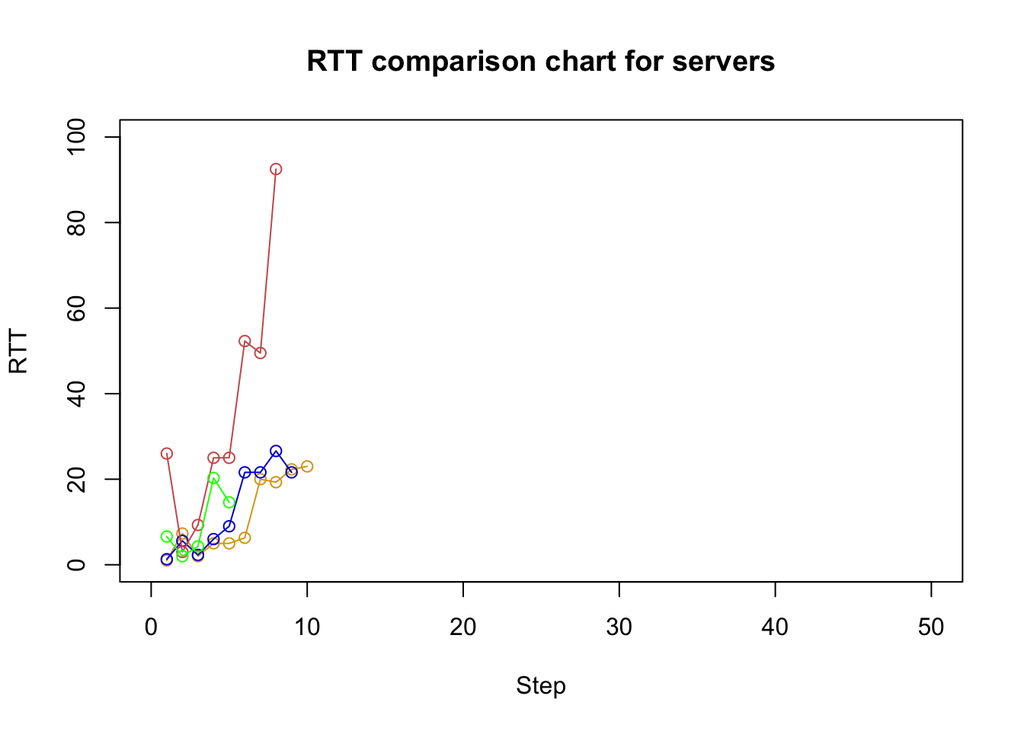

[figure not shown]

#### **Оценка результата**

По полученным в ходе лабораторной работы данным, можно сделать вывод что самое минимальное время было затрачено на обращение к OnLime DNS, а максимальное к OpenDNS.

#### **Вывод**

В данной лабораторной работе я проанализировал сетевые параметры публичных DNS серверов